# stratification-model

Sam Bashevkin

2023-10-26

# Setup

packages

```r
library(dplyr)
library(readr)
library(tidyr)
library(lubridate)
library(stringr)
library(ggplot2)
library(GGally)
library(mgcv)
library(itsadug)
library(downloadthis)
library(patchwork)
```

read data

```r
test_train_cutoff<-as_date("2022-09-29")

d<-read_csv("data/X2_ModelInputs_v2.csv")%>%
  filter(if_any(everything(), ~ !is.na(.x)))%>% # Remove empty rows
  rename(NDOI=`NDOI (cfs)`, Weak_ebb_flood=`Weak Ebb-Flood (m)`, Stratification=`Stratification (PSU)`,
         X2_surface=`X2_TopSalinity (km)`, X2_bottom=`X2_BottomSalinity (km)`, Wind_speed=`Wind Speed (m/s)`)%>%
  mutate(Date=dmy(Date))%>%
  arrange(Date)%>%
  mutate(data=if_else(Date>test_train_cutoff, "Testing", "Training"),
         NDOI_change=NDOI-lag(NDOI),
         NDOI_change_mag=abs(NDOI_change),
         NDOI_change_sign=sign(NDOI_change),
         NDOI_prop_change=NDOI_change/lag(NDOI),
         Weak_ebb_flood_1=lag(Weak_ebb_flood),
         Weak_ebb_flood_2=lag(Weak_ebb_flood, 2))
d_train<-d%>%
  filter(data=="Training")

# Create variable with residuals of X2_surface by NDOI
X2_surface_model<-lm(X2_surface~log(NDOI), data=d_train)

d_train<-d_train%>%
  mutate(X2_surface_resid=residuals(X2_surface_model))

d_long<-d_train%>%
  select(-NDOI_change_mag, -NDOI_change_sign)%>%
  pivot_longer(cols = c(NDOI, NDOI_change, NDOI_prop_change,
                        Weak_ebb_flood, Stratification, Wind_speed,
                        X2_surface, X2_bottom),
               names_to="variable",
               values_to="value")
```

# Plots

full timeseries

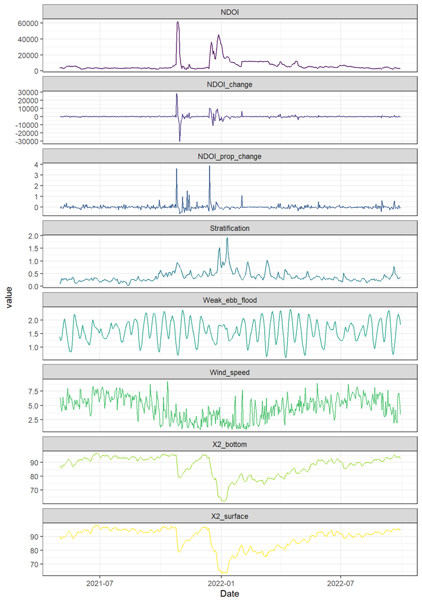

```r
ggplot(d_long, aes(x=Date, y=value, color=variable))+
  geom_line()+
  facet_wrap(~variable, ncol=1, scales="free_y")+
  scale_color_viridis_d()+
  theme_bw()+
  theme(legend.position="none")
```

zoomed-in timeseries for May through September of 2022

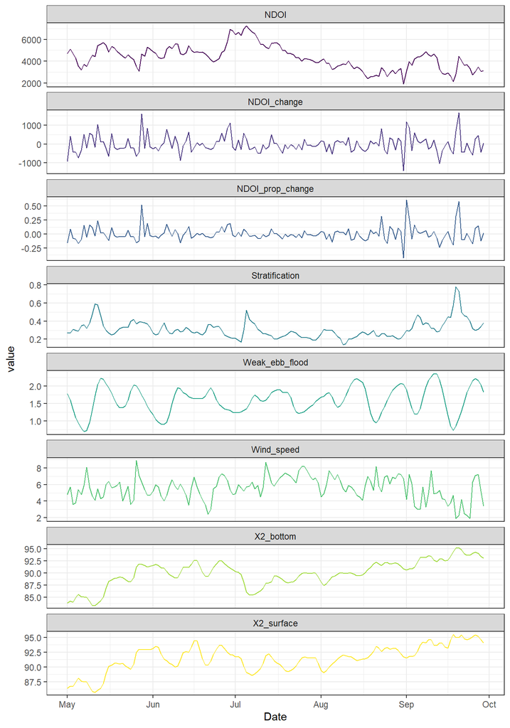

```r
ggplot(filter(d_long, year(Date)==2022 & month(Date)>=5), aes(x=Date, y=value, color=variable))+
  geom_line()+
  facet_wrap(~variable, ncol=1, scales="free_y")+
  scale_color_viridis_d()+
  theme_bw()+
  theme(legend.position="none")
```

Weak_ebb_flood vs stratification

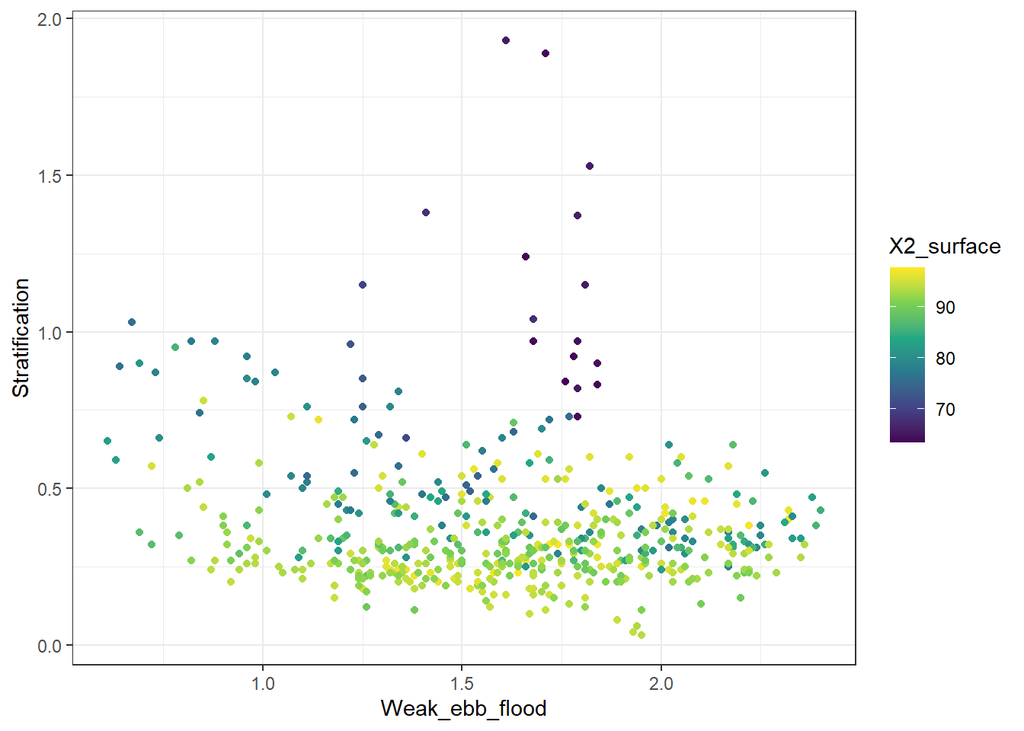

```r
ggplot(d_train, aes(x=Weak_ebb_flood, y=Stratification, color=X2_surface))+
  geom_point()+
  scale_color_viridis_c()+
  theme_bw()
```

X2 vs stratification

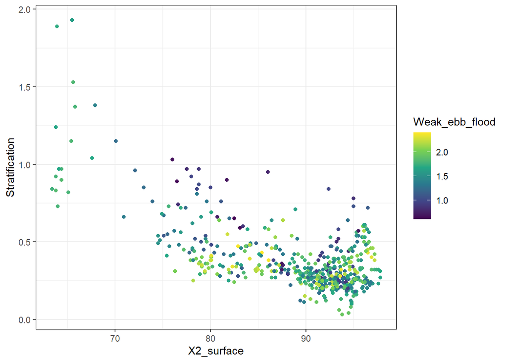

```r
ggplot(d_train, aes(x=X2_surface, y=Stratification, color=Weak_ebb_flood))+
  geom_point()+
  scale_color_viridis_c()+
  theme_bw()
```

X2 residual vs stratification

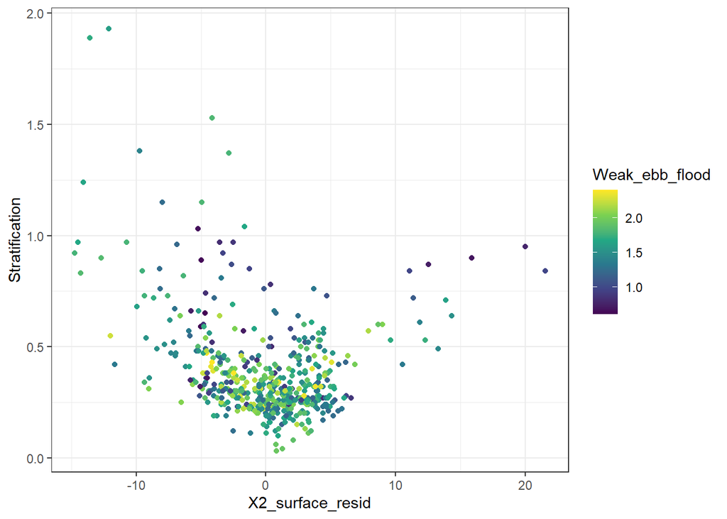

```r
ggplot(d_train, aes(x=X2_surface_resid, y=Stratification, color=Weak_ebb_flood))+
  geom_point()+
  scale_color_viridis_c()+
  theme_bw()
```

Wind speed vs stratification

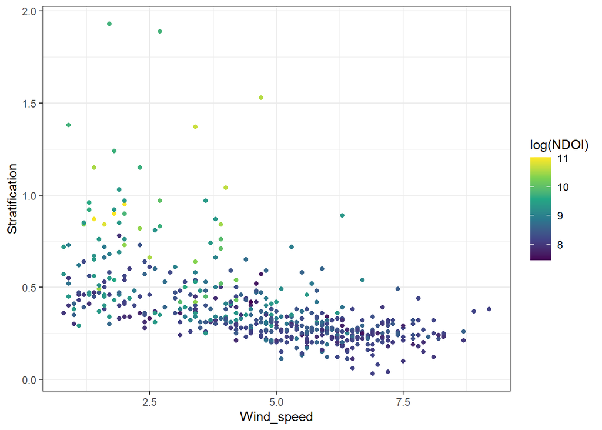

```r
ggplot(d_train, aes(x=Wind_speed, y=Stratification, color=log(NDOI)))+
  geom_point()+
  scale_color_viridis_c()+
  theme_bw()
```

NDOI vs stratification

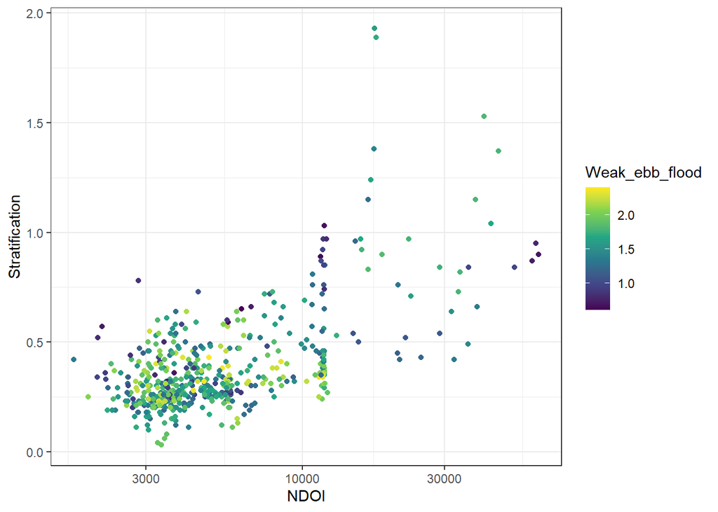

```r
ggplot(d_train, aes(x=NDOI, y=Stratification, color=Weak_ebb_flood))+
  geom_point()+
  scale_x_log10()+
  scale_color_viridis_c()+
  theme_bw()
```

NDOI change vs stratification

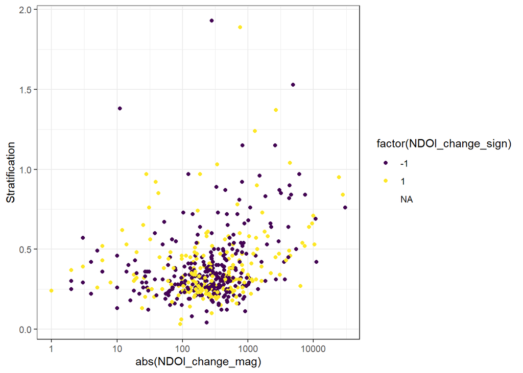

```r
ggplot(d_train, aes(x=abs(NDOI_change_mag), y=Stratification, color=factor(NDOI_change_sign)))+
  geom_point()+
  scale_x_log10()+
  scale_color_viridis_d()+
  theme_bw()
```

NDOI prop change vs stratification

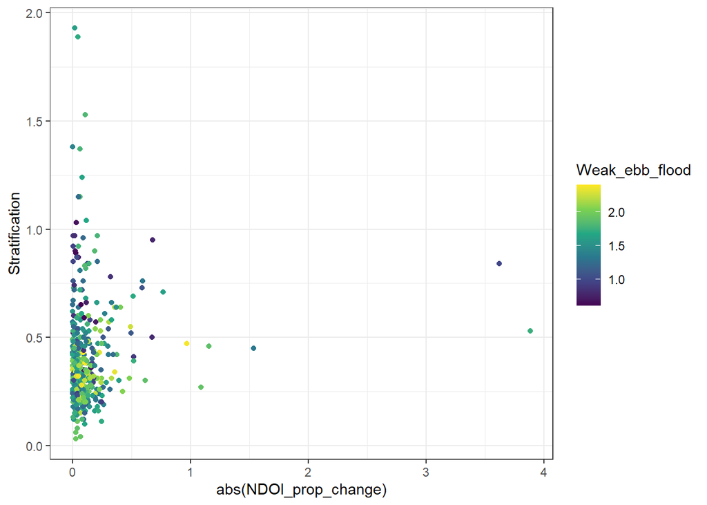

```r
ggplot(d_train, aes(x=abs(NDOI_prop_change), y=Stratification, color=Weak_ebb_flood))+
  geom_point()+
  #scale_x_log10()+
  scale_color_viridis_c()+
  theme_bw()
```

NDOI vs X2 with trend line used for residuals

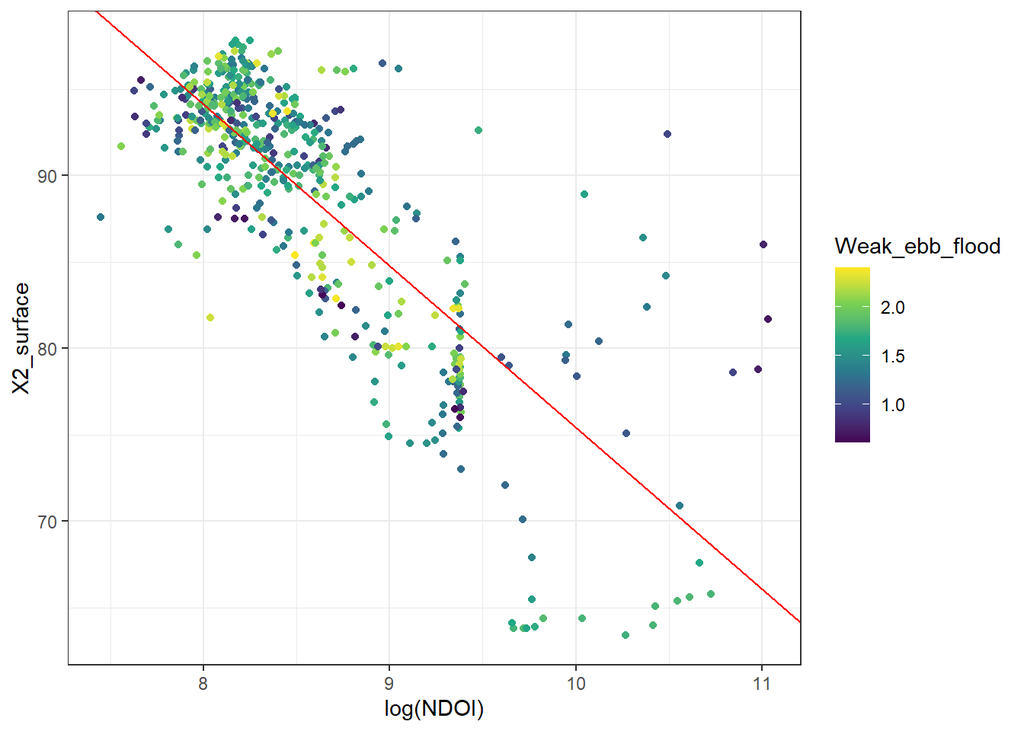

```r
ggplot(d_train, aes(x=log(NDOI), y=X2_surface, color=Weak_ebb_flood))+
  geom_point()+
  geom_abline(slope=coef(X2_surface_model)[2], intercept=coef(X2_surface_model)[1], color="red")+
  scale_color_viridis_c()+
  theme_bw()
```

NDOI change vs X2

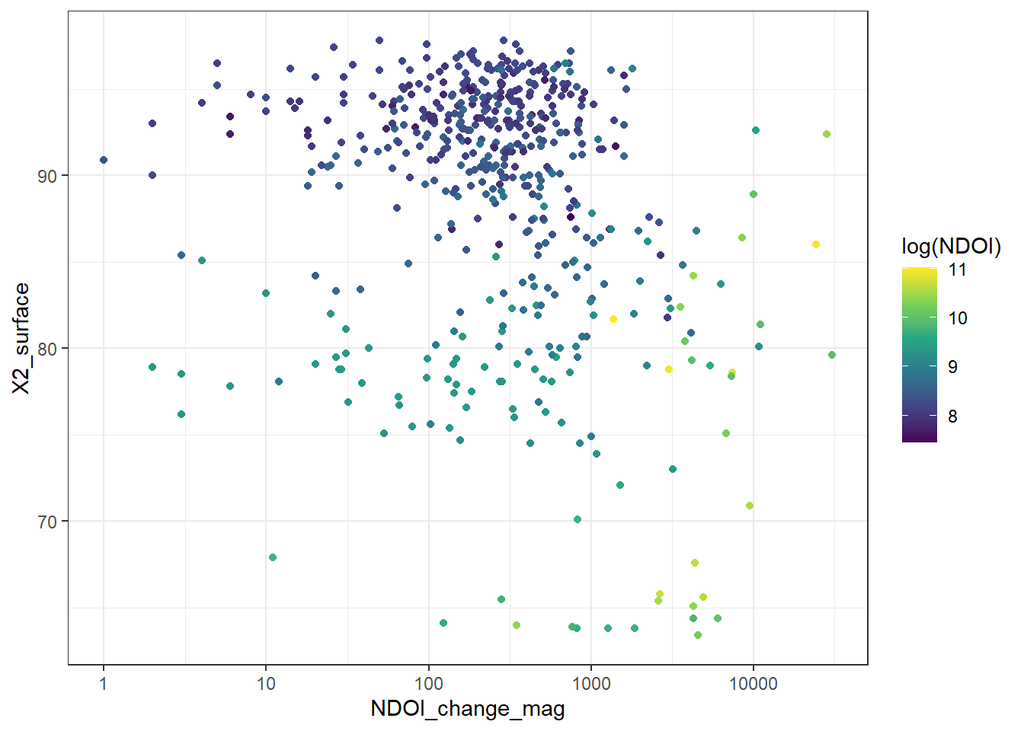

```r
ggplot(d_train, aes(x=NDOI_change_mag, y=X2_surface, color=log(NDOI)))+
  geom_point()+
  scale_x_log10()+
  scale_color_viridis_c()+
  theme_bw()
```

Pairs plot of all variables

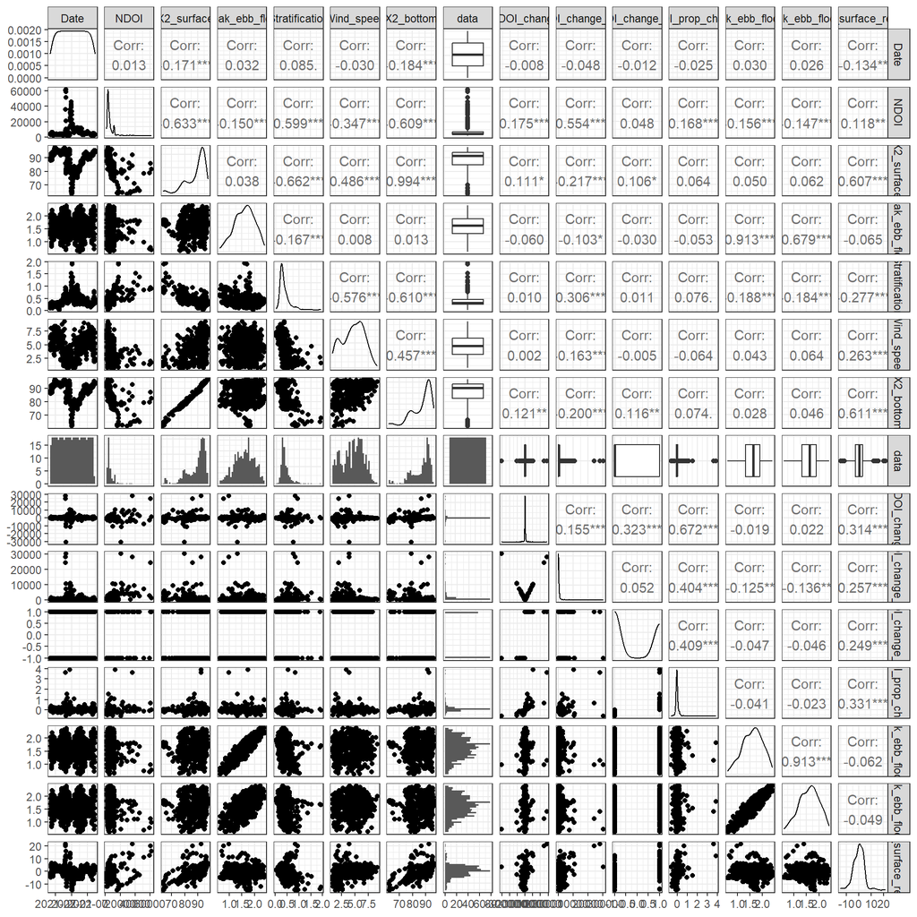

```r
ggpairs(d_train)+
  theme_bw()
```

Takeaways to inform model construction 1. NDOI_ _change_mag is highly correlated with NDOI, but NDOI_change is not 2. X2 is highly correlated with NDOI 3. Weak_ebb_flood not correlated with anything (except slightly with stratification)

# Model

Prepare data

```r
d_model<-d_train%>%
  drop_na()%>%
  mutate(across(c(Stratification, NDOI), list(l=~log(.x))),
         across(c(NDOI, NDOI_l, NDOI_change, Weak_ebb_flood, Weak_ebb_flood_1, Weak_ebb_flood_2, Wind_speed, X2_surface_resid), list(s=~(.x-mean(.x))/sd(.x))))
```

model function

```r
gam_model<-function(form, model_data=d_model, model_family="gaussian", plot_acf=FALSE){
  par(mfrow=c(2,2))
  NOAR<-bam(form, data=model_data, family=model_family) # first fit model with autoregressive (AR) term
  par(mfrow=c(1,1))
  r <- start_value_rho(NOAR, plot=plot_acf) # Estimate rho for autoregressive term
  if(model_family=="gaussian"){
    m<-bam(form, data=model_data, rho=r, family=model_family) # fit autoregressive model
  }else{
    m<-bam(form, data=model_data, rho=r, family=model_family, discrete=T) # fit autoregressive model
  }
  if(plot_acf){
    suppressWarnings(acf_resid(m))
  }
  par(mfrow=c(2,2))
  gam.check(m)
  print(summary(m))
  par(mfrow=c(1,1))
  return(m)
}
```

## m1

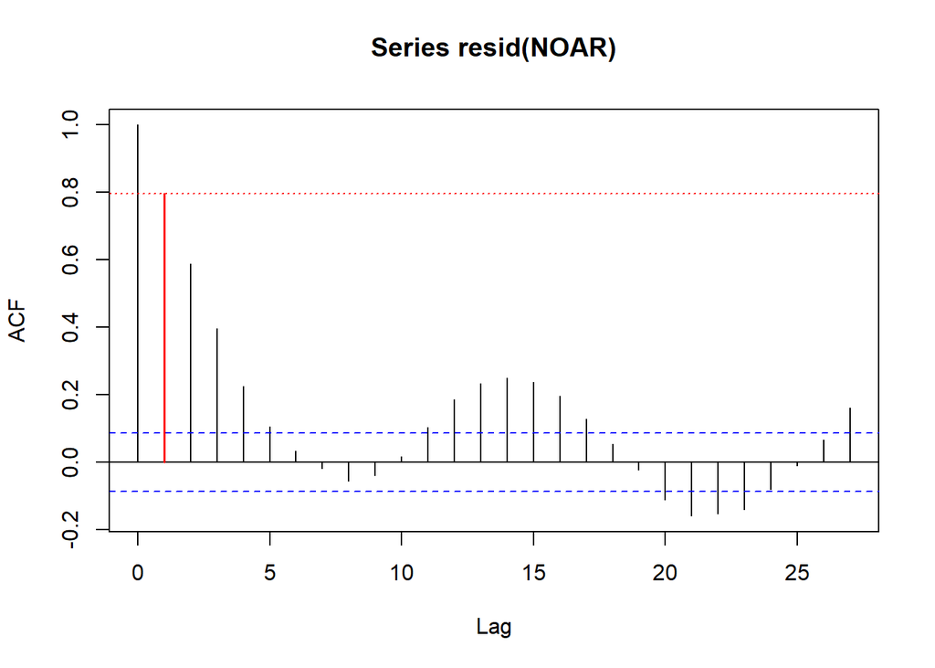

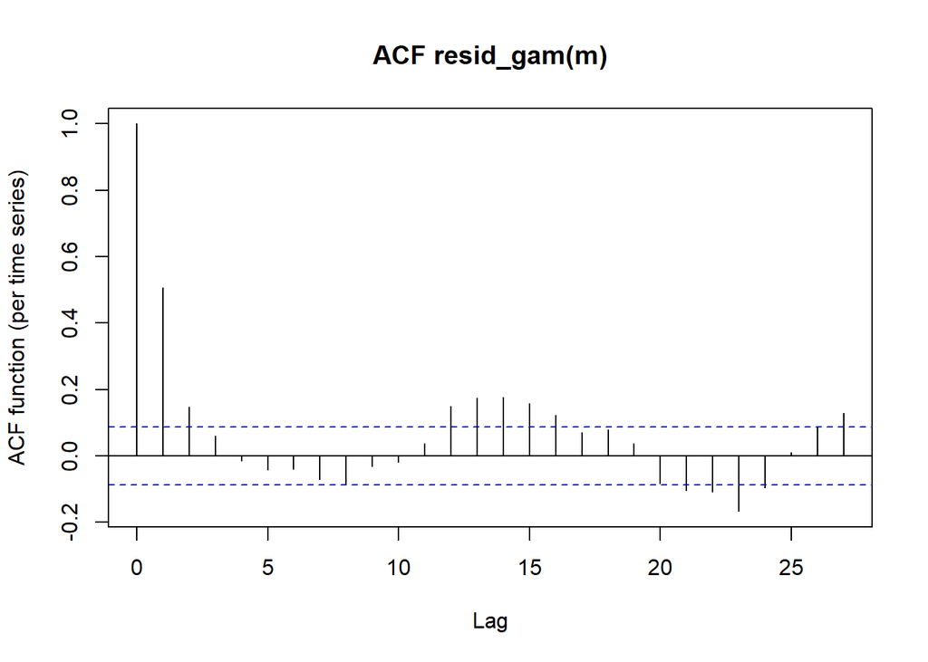

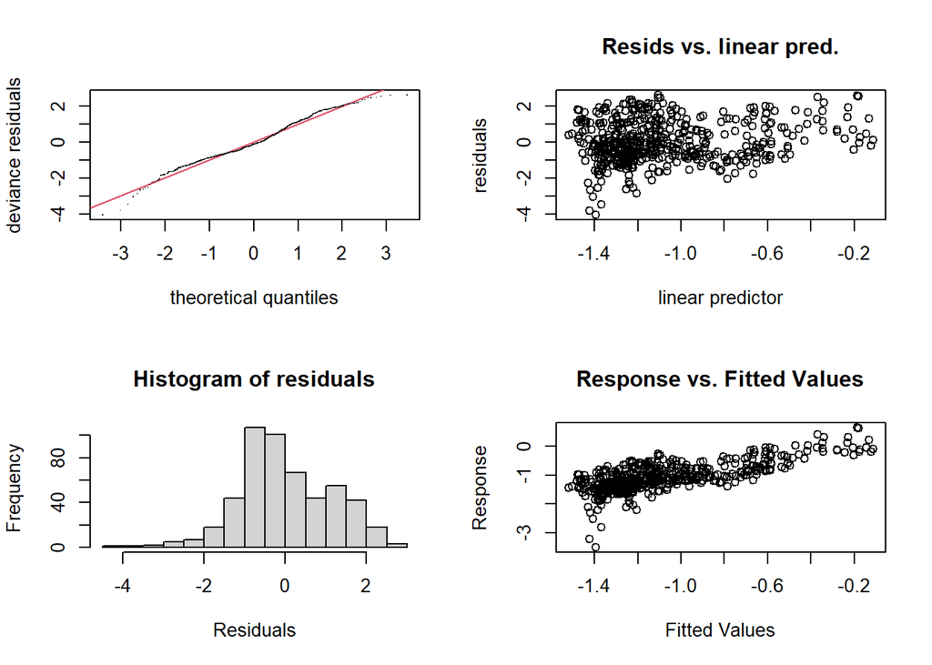

```
##
## Method: fREML   Optimizer: perf chol
## $grad
## [1] -4.911462e-06 -2.565546e-06 -2.056101e-06 -3.369047e-06 -3.427258e-13
##
## $hess
##               [,1]          [,2]          [,3]         [,4]         [,5]
## [1,]  4.911428e-06  8.755882e-12 -1.193012e-13 5.194031e-12 4.434276e-07
## [2,]  8.755882e-12  2.565785e-06 -7.539972e-12 9.978938e-11 4.333148e-06
## [3,] -1.193012e-13 -7.539972e-12  2.056089e-06 2.901156e-12 6.978315e-09
## [4,]  5.194031e-12  9.978938e-11  2.901156e-12 3.369046e-06 1.448889e-06
## [5,]  4.434276e-07  4.333148e-06  6.978315e-09 1.448889e-06 7.836171e-01
##
## Model rank =  46 / 46
##
## Basis dimension (k) checking results. Low p-value (k-index<1) may
## indicate that k is too low, especially if edf is close to k'.
##
##                         k'  edf k-index p-value
## s(NDOI_l_s)           9.00 1.00    1.02   0.760
## s(NDOI_change_s)      9.00 1.00    0.92   0.035 *
## s(Weak_ebb_flood_s)   9.00 1.00    0.90   0.010 **
## s(Wind_speed_s)       9.00 1.00    0.76  <2e-16 ***
## s(X2_surface_resid_s) 9.00 2.89    0.88  <2e-16 ***
## ---
## Signif. codes:  0 '***' 0.001 '**' 0.01 '*' 0.05 '.' 0.1 ' ' 1
##
## Family: Scaled t(5.652,0.269)
## Link function: identity
##
## Formula:
## Stratification_l ~ s(NDOI_l_s) + s(NDOI_change_s) + s(Weak_ebb_flood_s) +
##     s(Wind_speed_s) + s(X2_surface_resid_s)
##
## Parametric coefficients:
##             Estimate Std. Error t value Pr(>|t|)
## (Intercept) -1.08635    0.04001  -27.15   <2e-16 ***
## ---
## Signif. codes:  0 '***' 0.001 '**' 0.01 '*' 0.05 '.' 0.1 ' ' 1
##
## Approximate significance of smooth terms:
##                         edf Ref.df      F  p-value
## s(NDOI_l_s)           1.000  1.000 36.267  < 2e-16 ***
## s(NDOI_change_s)      1.000  1.000  0.437   0.5090
## s(Weak_ebb_flood_s)   1.000  1.000  5.572   0.0186 *
## s(Wind_speed_s)       1.000  1.000 40.663  < 2e-16 ***
## s(X2_surface_resid_s) 2.889  3.868  6.700 4.84e-05 ***
## ---
## Signif. codes:  0 '***' 0.001 '**' 0.01 '*' 0.05 '.' 0.1 ' ' 1
##
## R-sq.(adj) =  0.515   Deviance explained =   43%
## fREML = 562.83  Scale est. = 1         n = 515
```

```r
m1<-gam_model(Stratification_l ~ s(NDOI_l_s) +s(NDOI_change_s) + s(Weak_ebb_flood_s) + s(Wind_speed_s) + s(X2_surface_resid_s), plot_acf=TRUE, model_family="scat")
```

Only `X2_surface_resid_s` is showing as a nonlinear effect, so making the rest linear

## m2

```r
m2<-gam_model(Stratification_l ~ NDOI_l_s + NDOI_change_s + Weak_ebb_flood_s + Wind_speed_s + s(X2_surface_resid_s), model_family="scat")
```

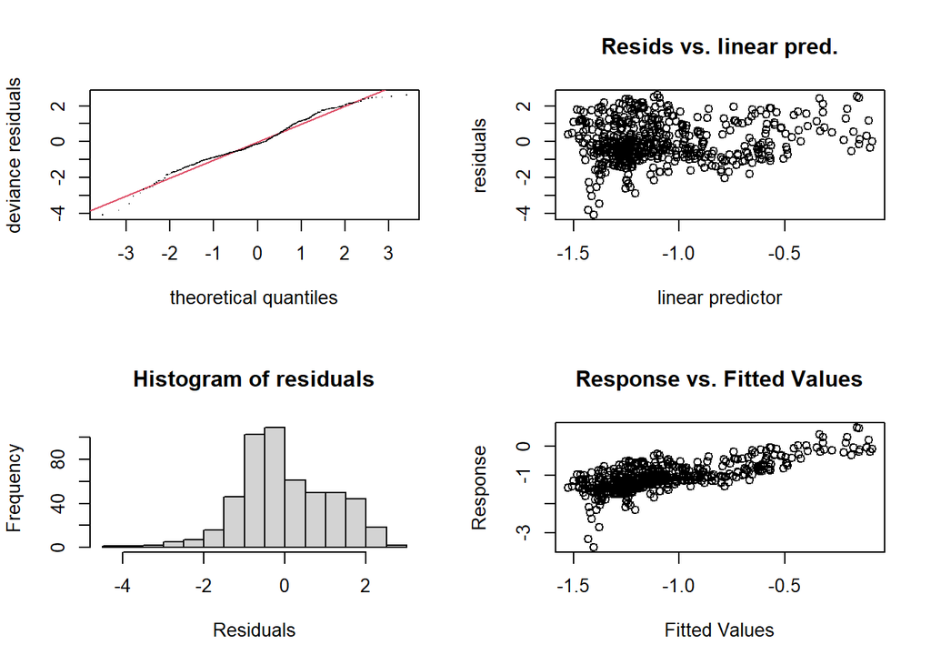

```
##
## Method: fREML   Optimizer: perf chol
## $grad
## [1] 2.395308e-06
##
## $hess
##           [,1]
## [1,] 0.6090764
##
## Model rank =  14 / 14
##
## Basis dimension (k) checking results. Low p-value (k-index<1) may
## indicate that k is too low, especially if edf is close to k'.
##
##                         k'  edf k-index p-value
## s(X2_surface_resid_s) 9.00 2.64    0.88  <2e-16 ***
## ---
## Signif. codes:  0 '***' 0.001 '**' 0.01 '*' 0.05 '.' 0.1 ' ' 1
##
## Family: Scaled t(5.904,0.274)
## Link function: identity
##
## Formula:
## Stratification_l ~ NDOI_l_s + NDOI_change_s + Weak_ebb_flood_s +
##     Wind_speed_s + s(X2_surface_resid_s)
##
## Parametric coefficients:
##                  Estimate Std. Error t value Pr(>|t|)
## (Intercept)      -1.08061    0.04453 -24.267  < 2e-16 ***
## NDOI_l_s          0.19987    0.03335   5.994 3.89e-09 ***
## NDOI_change_s    -0.01139    0.01081  -1.053  0.29263
## Weak_ebb_flood_s -0.05592    0.01847  -3.028  0.00259 **
## Wind_speed_s     -0.07685    0.01204  -6.381 3.96e-10 ***
## ---
## Signif. codes:  0 '***' 0.001 '**' 0.01 '*' 0.05 '.' 0.1 ' ' 1
##
## Approximate significance of smooth terms:
##                         edf Ref.df     F  p-value
## s(X2_surface_resid_s) 2.635  3.548 7.521 2.68e-05 ***
## ---
## Signif. codes:  0 '***' 0.001 '**' 0.01 '*' 0.05 '.' 0.1 ' ' 1
##
## R-sq.(adj) =   0.51   Deviance explained = 42.6%
## fREML = 521.12  Scale est. = 1         n = 515
```

```r
AIC(m1, m2)
```

```
##          df       AIC
## m1 11.35641 -201.1000
## m2 11.19649 -273.8531
```

`NDOI_change_s` doesn’t have a significant effect, so removing it

## m3

```r
m3<-gam_model(Stratification_l ~ NDOI_l_s  + Weak_ebb_flood_s + Wind_speed_s + s(X2_surface_resid_s), model_family="scat")
```

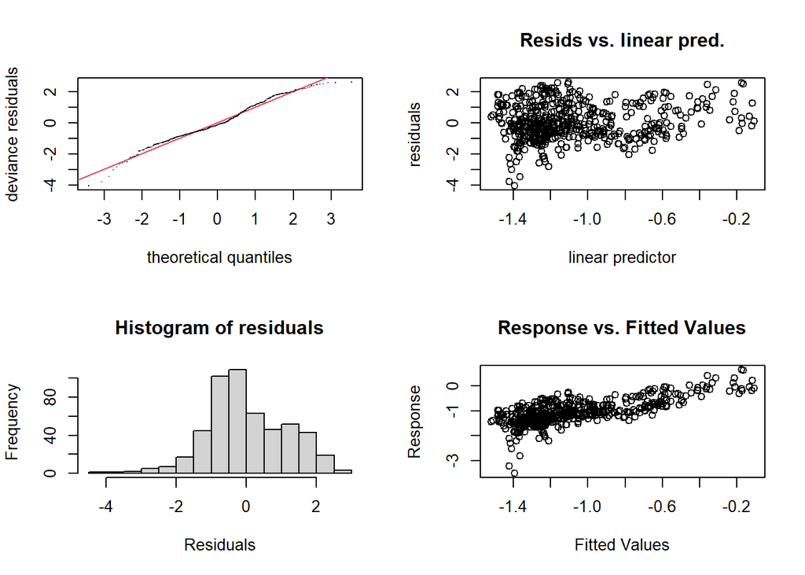

```
##
## Method: fREML   Optimizer: perf chol
## $grad
## [1] 1.790631e-06
##
## $hess
##           [,1]
## [1,] 0.7149889
##
## Model rank =  13 / 13
##
## Basis dimension (k) checking results. Low p-value (k-index<1) may
## indicate that k is too low, especially if edf is close to k'.
##
##                         k'  edf k-index p-value
## s(X2_surface_resid_s) 9.00 2.68    0.87  <2e-16 ***
## ---
## Signif. codes:  0 '***' 0.001 '**' 0.01 '*' 0.05 '.' 0.1 ' ' 1
##
## Family: Scaled t(5.766,0.274)
## Link function: identity
##
## Formula:
## Stratification_l ~ NDOI_l_s + Weak_ebb_flood_s + Wind_speed_s +
##     s(X2_surface_resid_s)
##
## Parametric coefficients:
##                  Estimate Std. Error t value Pr(>|t|)
## (Intercept)      -1.08337    0.04424 -24.486  < 2e-16 ***
## NDOI_l_s          0.19694    0.03330   5.914 6.14e-09 ***
## Weak_ebb_flood_s -0.04771    0.01859  -2.566   0.0106 *
## Wind_speed_s     -0.07850    0.01209  -6.491 2.03e-10 ***
## ---
## Signif. codes:  0 '***' 0.001 '**' 0.01 '*' 0.05 '.' 0.1 ' ' 1
##
## Approximate significance of smooth terms:
##                         edf Ref.df     F  p-value
## s(X2_surface_resid_s) 2.679  3.558 7.444 3.09e-05 ***
## ---
## Signif. codes:  0 '***' 0.001 '**' 0.01 '*' 0.05 '.' 0.1 ' ' 1
##
## R-sq.(adj) =  0.506   Deviance explained = 42.1%
## fREML = 521.93  Scale est. = 1         n = 515
```

```r
AIC(m1, m2, m3)
```

```
##          df       AIC
## m1 11.35641 -201.1000
## m2 11.19649 -273.8531
## m3 10.13182 -264.0035
```

Nope, it was better with `NDOI_change_s`

Do we need interactions?

## m4

```r
m4<-gam_model(Stratification_l ~ (NDOI_l_s + Wind_speed_s + NDOI_change_s + Weak_ebb_flood_s)^2 + s(X2_surface_resid_s), model_family="scat")
```

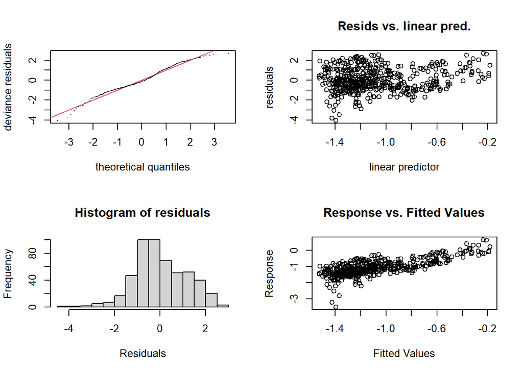

```
##
## Method: fREML   Optimizer: perf chol
## $grad
## [1] 4.776823e-07
##
## $hess
##           [,1]
## [1,] 0.5497283
##
## Model rank =  20 / 20
##
## Basis dimension (k) checking results. Low p-value (k-index<1) may
## indicate that k is too low, especially if edf is close to k'.
##
##                         k'  edf k-index p-value
## s(X2_surface_resid_s) 9.00 2.65    0.87  <2e-16 ***
## ---
## Signif. codes:  0 '***' 0.001 '**' 0.01 '*' 0.05 '.' 0.1 ' ' 1
##
## Family: Scaled t(5.634,0.269)
## Link function: identity
##
## Formula:
## Stratification_l ~ (NDOI_l_s + Wind_speed_s + NDOI_change_s +
##     Weak_ebb_flood_s)^2 + s(X2_surface_resid_s)
##
## Parametric coefficients:
##                                 Estimate Std. Error t value Pr(>|t|)
## (Intercept)                    -1.073149   0.044339 -24.203  < 2e-16 ***
## NDOI_l_s                        0.208097   0.034244   6.077 2.43e-09 ***
## Wind_speed_s                   -0.077530   0.011979  -6.472 2.30e-10 ***
## NDOI_change_s                  -0.019732   0.023977  -0.823  0.41091
## Weak_ebb_flood_s               -0.048855   0.018287  -2.672  0.00779 **
## NDOI_l_s:Wind_speed_s           0.025980   0.011313   2.296  0.02207 *
## NDOI_l_s:NDOI_change_s          0.011756   0.012654   0.929  0.35334
## NDOI_l_s:Weak_ebb_flood_s      -0.005330   0.015677  -0.340  0.73400
## Wind_speed_s:NDOI_change_s      0.005695   0.012177   0.468  0.64022
## Wind_speed_s:Weak_ebb_flood_s   0.014746   0.010328   1.428  0.15397
## NDOI_change_s:Weak_ebb_flood_s  0.009612   0.014182   0.678  0.49823
## ---
## Signif. codes:  0 '***' 0.001 '**' 0.01 '*' 0.05 '.' 0.1 ' ' 1
##
## Approximate significance of smooth terms:
##                         edf Ref.df     F  p-value
## s(X2_surface_resid_s) 2.653  3.581 6.133 0.000197 ***
## ---
## Signif. codes:  0 '***' 0.001 '**' 0.01 '*' 0.05 '.' 0.1 ' ' 1
##
## R-sq.(adj) =  0.509   Deviance explained =   43%
## fREML =  543.7  Scale est. = 1         n = 515
```

```r
AIC(m1, m2, m3, m4)
```

```
##          df       AIC
## m1 11.35641 -201.1000
## m2 11.19649 -273.8531
## m3 10.13182 -264.0035
## m4 17.28391 -273.3029
```

Only NDOI_l_s:Wind_speed_s is significant

## m5

```r
m5<-gam_model(Stratification_l ~ NDOI_l_s * Wind_speed_s + NDOI_change_s + Weak_ebb_flood_s + s(X2_surface_resid_s), model_family="scat")
```

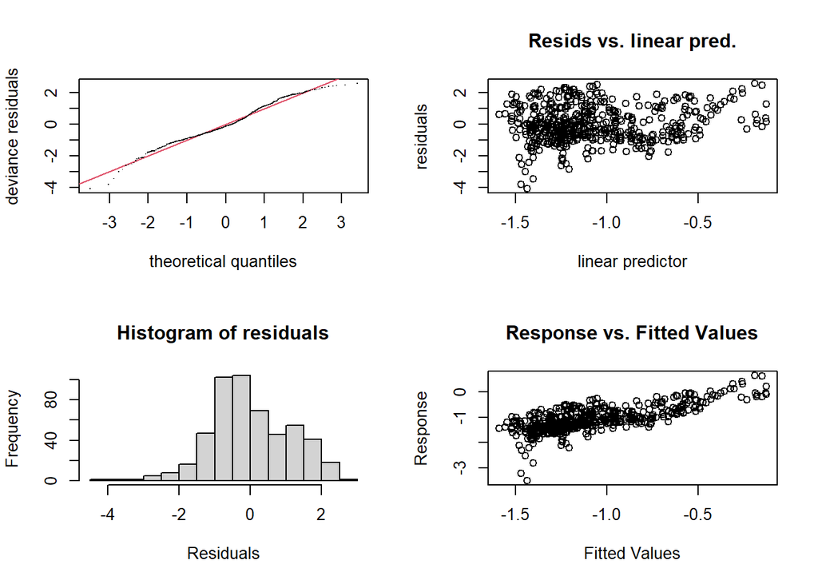

```
##
## Method: fREML   Optimizer: perf chol
## $grad
## [1] 1.02619e-10
##
## $hess
##           [,1]
## [1,] 0.6233003
##
## Model rank =  15 / 15
##
## Basis dimension (k) checking results. Low p-value (k-index<1) may
## indicate that k is too low, especially if edf is close to k'.
##
##                         k'  edf k-index p-value
## s(X2_surface_resid_s) 9.00 2.66    0.87   0.005 **
## ---
## Signif. codes:  0 '***' 0.001 '**' 0.01 '*' 0.05 '.' 0.1 ' ' 1
##
## Family: Scaled t(6.28,0.276)
## Link function: identity
##
## Formula:
## Stratification_l ~ NDOI_l_s * Wind_speed_s + NDOI_change_s +
##     Weak_ebb_flood_s + s(X2_surface_resid_s)
##
## Parametric coefficients:
##                        Estimate Std. Error t value Pr(>|t|)
## (Intercept)           -1.066859   0.045432 -23.482  < 2e-16 ***
## NDOI_l_s               0.216310   0.034002   6.362 4.47e-10 ***
## Wind_speed_s          -0.076301   0.011944  -6.389 3.80e-10 ***
## NDOI_change_s         -0.008259   0.010820  -0.763  0.44561
## Weak_ebb_flood_s      -0.060582   0.018405  -3.292  0.00107 **
## NDOI_l_s:Wind_speed_s  0.033366   0.010879   3.067  0.00228 **
## ---
## Signif. codes:  0 '***' 0.001 '**' 0.01 '*' 0.05 '.' 0.1 ' ' 1
##
## Approximate significance of smooth terms:
##                         edf Ref.df     F  p-value
## s(X2_surface_resid_s) 2.657  3.575 8.173 9.47e-06 ***
## ---
## Signif. codes:  0 '***' 0.001 '**' 0.01 '*' 0.05 '.' 0.1 ' ' 1
##
## R-sq.(adj) =  0.515   Deviance explained = 43.1%
## fREML = 514.96  Scale est. = 1         n = 515
```

```r
AIC(m1, m2, m3, m4, m5)
```

```
##          df       AIC
## m1 11.35641 -201.1000
## m2 11.19649 -273.8531
## m3 10.13182 -264.0035
## m4 17.28391 -273.3029
## m5 12.21808 -284.8608
```

Model is better with NDOI_l_s:Wind_speed_s interaction so moving forward with m5

# Plot m5 results

Generate predictions

```r
newdata<-expand_grid(NDOI=seq(min(d_model$NDOI), max(d_model$NDOI), length.out=10),
                     Weak_ebb_flood=seq(min(d_model$Weak_ebb_flood), max(d_model$Weak_ebb_flood), length.out=10),
                     Wind_speed=seq(min(d_model$Wind_speed), max(d_model$Wind_speed), length.out=10),
                     NDOI_change=seq(min(d_model$NDOI_change), max(d_model$NDOI_change), length.out=10),
                     X2_surface_resid=seq(min(d_model$X2_surface_resid), max(d_model$X2_surface_resid), length.out=10))%>%
  mutate(NDOI_l=log(NDOI),
         NDOI_l_s=(NDOI_l-mean(d_model$NDOI_l))/sd(d_model$NDOI_l),
         Weak_ebb_flood_s=(Weak_ebb_flood-mean(d_model$Weak_ebb_flood))/sd(d_model$Weak_ebb_flood),
         Wind_speed_s=(Wind_speed-mean(d_model$Wind_speed))/sd(d_model$Wind_speed),
         NDOI_change_s=(NDOI_change-mean(d_model$NDOI_change))/sd(d_model$NDOI_change),
         X2_surface_resid_s=(X2_surface_resid-mean(d_model$X2_surface_resid))/sd(d_model$X2_surface_resid))

m4b_pred<-predict(m5, newdata=newdata, se=TRUE)

newdata_pred<-newdata%>%
  mutate(Stratification_l=m4b_pred$fit,
         Stratification_l_se=m4b_pred$se.fit,
         Stratification_l_u95=Stratification_l+Stratification_l_se*qnorm(0.95),
         Stratification_l_l95=Stratification_l-Stratification_l_se*qnorm(0.95),
         across(c(Stratification_l, Stratification_l_u95, Stratification_l_l95), exp))%>%
  rename_with(~str_remove(.x, fixed("_l")), c(Stratification_l, Stratification_l_u95, Stratification_l_l95))
```

Plotting function

```r
strat_pred_plot<-function(xvar, colorvar, palette="D"){
  othervars<-c("NDOI", "Weak_ebb_flood", "NDOI_change", "Wind_speed", "X2_surface_resid")
  othervars<-othervars[-which(othervars%in%c(xvar, colorvar))]

  name_unit<-function(var){
    unit<-case_when(var%in%c("NDOI", "NDOI_change") ~ "cfs",
              var%in%c("Weak_ebb_flood") ~ "m",
              var%in%c("Wind_speed") ~ "m/s",
              var%in%c("X2_surface_resid") ~ "km")

    out<-paste0(str_replace_all(var, "_", " "), " (", unit, ")")
  }

  ggplot(
    filter(newdata_pred,
           .data[[colorvar]]%in%unique(.data[[colorvar]])[c(1, 5, 10)] &
             .data[[othervars[1]]]%in%unique(.data[[othervars[1]]])[5] &
             .data[[othervars[2]]]%in%unique(.data[[othervars[2]]])[5] &
             .data[[othervars[3]]]%in%unique(.data[[othervars[3]]])[5]), aes(x=.data[[xvar]], y=Stratification, ymin=Stratification_l95, ymax=Stratification_u95, fill=.data[[colorvar]], color=.data[[colorvar]], group=.data[[colorvar]]))+
    geom_ribbon(alpha=0.4, color=NA)+
    geom_line()+
    scale_fill_viridis_c(aesthetics = c("color", "fill"), end=ifelse(palette=="A", 0.8, 1), option=palette, name=name_unit(colorvar))+
    xlab(name_unit(xvar))+
    ylab("Stratification (PSU)")+
    theme_bw()+
    theme(axis.text.x=element_text(angle=45, hjust=1))
}
```

plot by NDOI

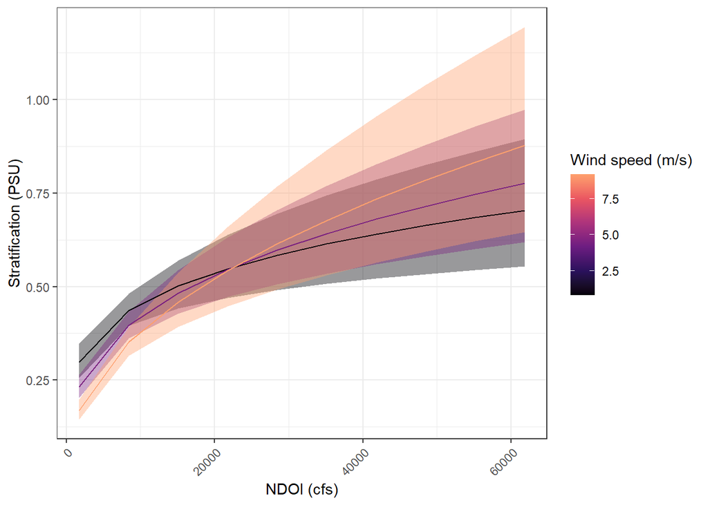

```r
p_NDOI<-strat_pred_plot(xvar="NDOI", colorvar="Wind_speed", palette="A")
p_NDOI
```

plot by Weak_ebb_flood

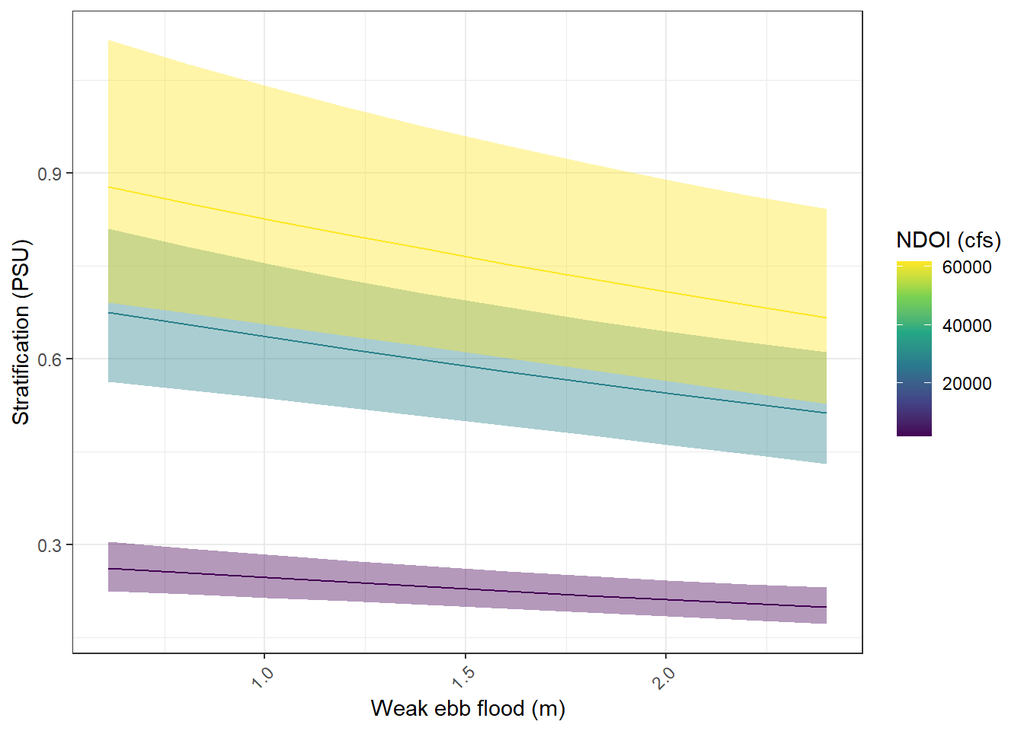

```r
p_ebb_flood<-strat_pred_plot(xvar="Weak_ebb_flood", colorvar="NDOI")
p_ebb_flood
```

plot by Wind speed

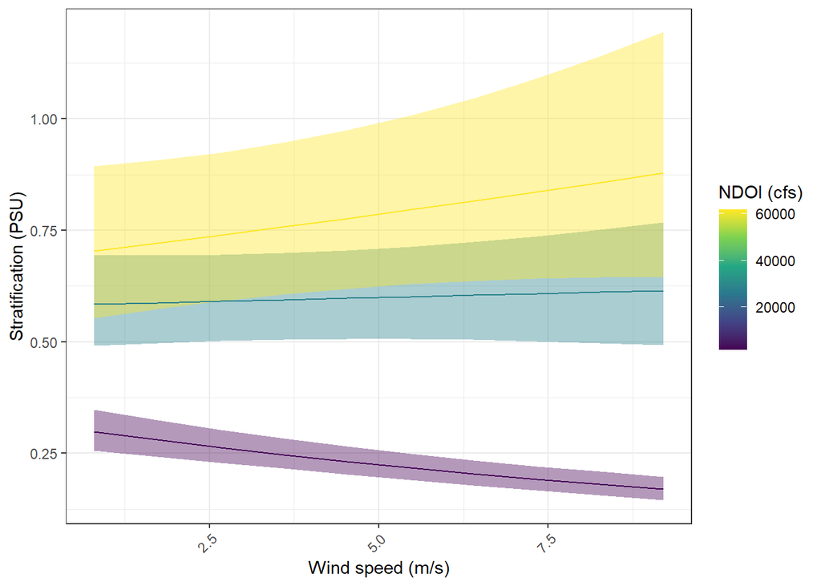

```r
p_Wind_speed<-strat_pred_plot(xvar="Wind_speed", colorvar="NDOI")
p_Wind_speed
```

plot by NDOI change

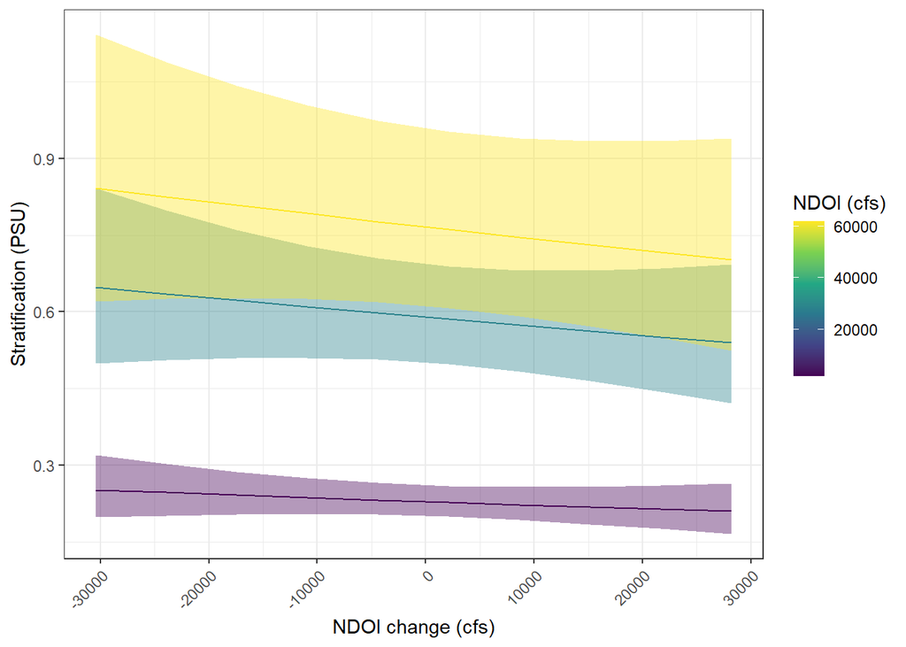

```r
p_NDOI_change<-strat_pred_plot(xvar="NDOI_change", colorvar="NDOI")
p_NDOI_change
```

plot by X2_surface_resid

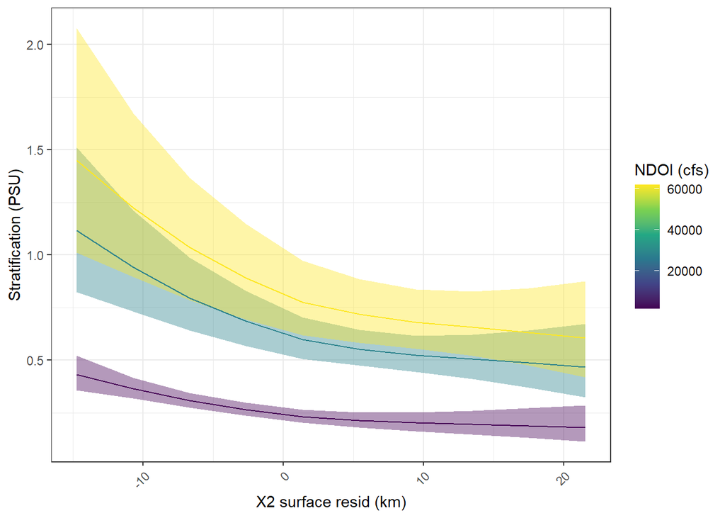

```r
p_X2_surface_resid<-strat_pred_plot(xvar="X2_surface_resid", colorvar="NDOI")
p_X2_surface_resid
```

Save all plots together

```r
p<-p_NDOI+p_ebb_flood+p_Wind_speed+p_NDOI_change+p_X2_surface_resid+plot_annotation(tag_levels="a", tag_suffix=")")+plot_layout(guides = "collect")

ggsave(plot=p, filename="figs/stratification model predictions.png", width=10, height=8)
```

# Cross validation

Testing data

```r
d_test<-d%>%
  filter(data=="Testing" & !is.na(X2_surface))


# Create variable with residuals of X2_surface by NDOI
X2_surface_model_test<-lm(X2_surface~log(NDOI), data=d_test)

d_test<-d_test%>%
  mutate(X2_surface_resid=residuals(X2_surface_model_test))%>%
  drop_na()%>%
  mutate(across(c(Stratification, NDOI), list(l=~log(.x))),
         across(c(NDOI, NDOI_l, NDOI_change, Weak_ebb_flood, Weak_ebb_flood_1, Weak_ebb_flood_2, Wind_speed, X2_surface_resid), list(s=~(.x-mean(d_model[[cur_column()]]))/sd(d_model[[cur_column()]]))))

d_test_pred<-d_test%>% # center and scale data based on original model inputs
  mutate(stratification_pred_l=predict(m5, newdata=.), # Generate model predictions
         stratification_pred=exp(stratification_pred_l),
         Stratification_diff=stratification_pred-Stratification,
         Stratification_diff_prop=Stratification_diff/Stratification)
```

Cross-validation statistics

```r
# RMSE
sqrt(mean((d_test_pred$Stratification_diff)^2))
```

```
## [1] 0.204428
```

```r
# Mean difference (for bias)
mean(d_test_pred$Stratification_diff)
```

```
## [1] -0.1069464
```

```r
# Pearson's correlation
cor(d_test_pred$Stratification, d_test_pred$stratification_pred, method = 'pearson')
```

```
## [1] 0.8642186
```

plot measured vs predicted

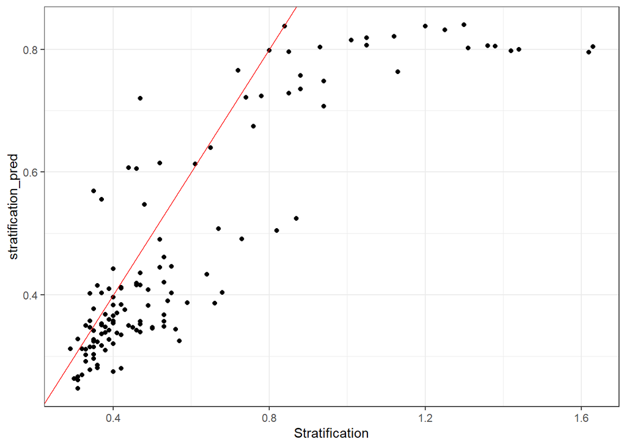

```r
ggplot(d_test_pred, aes(x=Stratification, y=stratification_pred))+
  geom_point()+
  geom_abline(intercept = 0, slope=1, color="red")+
  theme_bw()
```

plot diff vs outflow

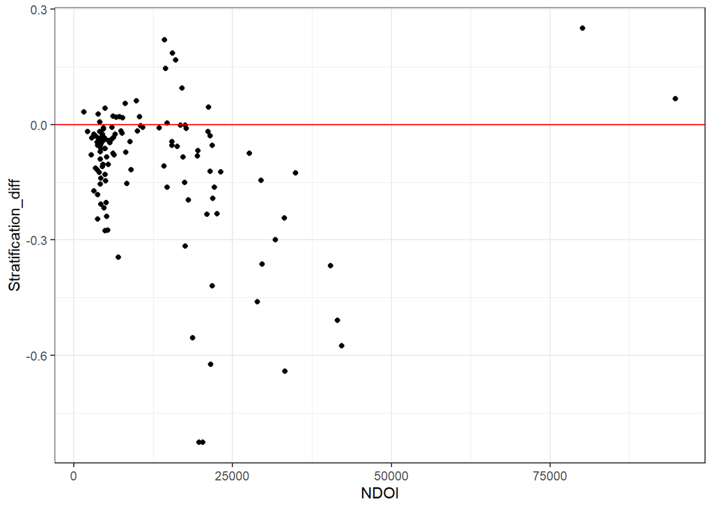

```r
ggplot(d_test_pred, aes(x=NDOI, y=Stratification_diff))+
  geom_point()+
  geom_hline(yintercept=0, color="red")+
  theme_bw()
```

plot diff vs outflow change

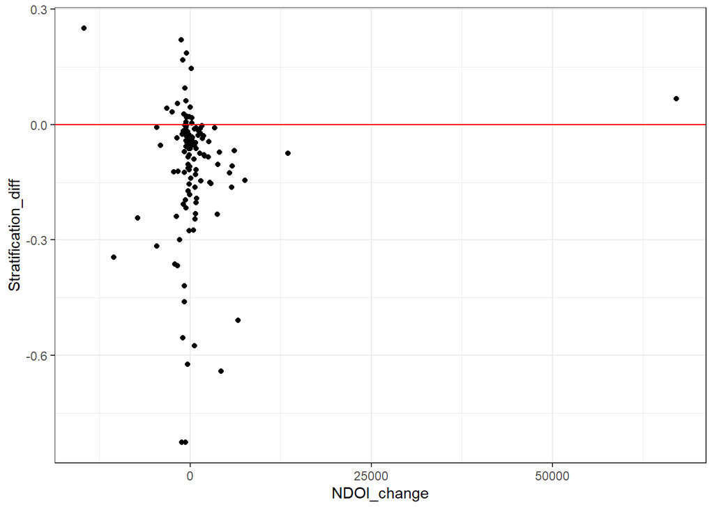

```r
ggplot(d_test_pred, aes(x=NDOI_change, y=Stratification_diff))+
  geom_point()+
  geom_hline(yintercept=0, color="red")+
  theme_bw()
```

plot diff vs Weak_ebb_flood

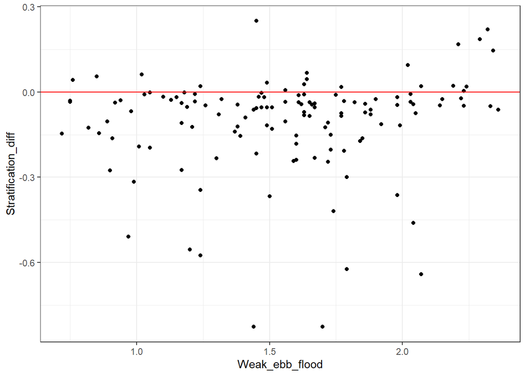

```r
ggplot(d_test_pred, aes(x=Weak_ebb_flood, y=Stratification_diff))+
  geom_point()+
  geom_hline(yintercept=0, color="red")+
  theme_bw()
```

plot diff vs Wind_speed

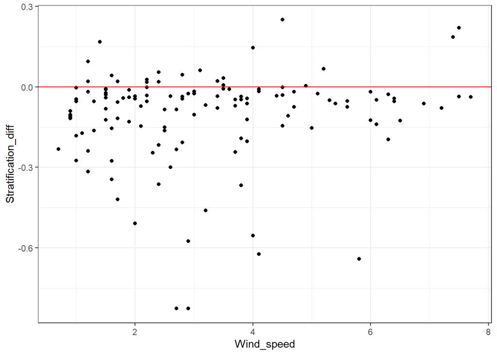

```r
ggplot(d_test_pred, aes(x=Wind_speed, y=Stratification_diff))+
  geom_point()+
  geom_hline(yintercept=0, color="red")+
  theme_bw()
```

plot diff vs X2_surface_resid

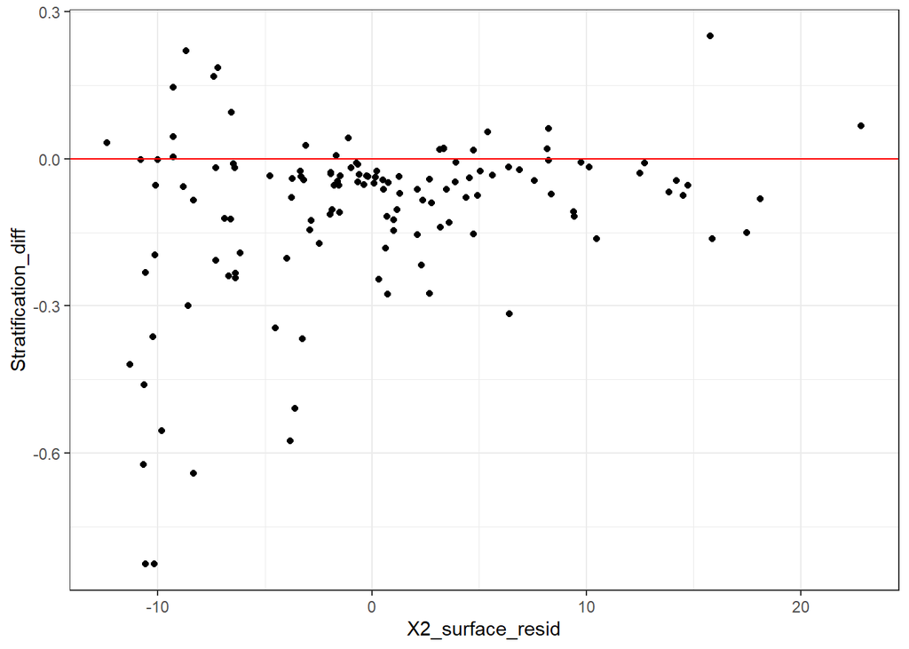

```r
ggplot(d_test_pred, aes(x=X2_surface_resid, y=Stratification_diff))+
  geom_point()+
  geom_hline(yintercept=0, color="red")+
  theme_bw()
```

plot diff vs X2_surface

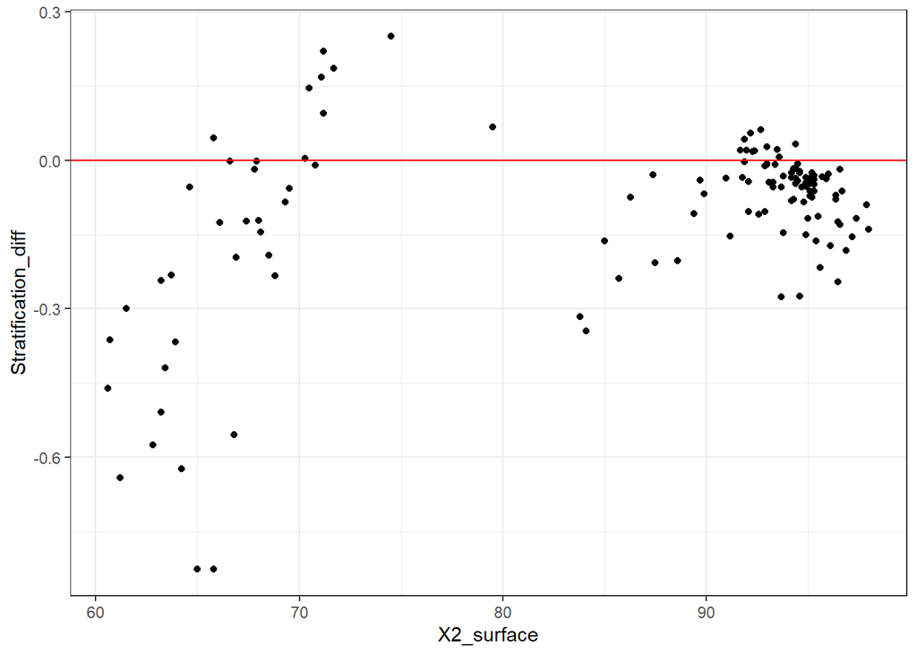

```r
ggplot(d_test_pred, aes(x=X2_surface, y=Stratification_diff))+
  geom_point()+
  geom_hline(yintercept=0, color="red")+
  theme_bw()
```